# Does Obamacare affect health positively?

Gabriel Florit

## Part 0: Introduction

It’s been more than six years since President Obama signed the Affordable Care Act into law. The administration credits Obamacare – as it is colloquially known – for lowering the number of uninsured residents: down 11 million since its passage, according to a March 2015 report by the Centers for Disease Control and Prevention.

The uninsured rate varies between states, from 17% in Texas to 5% in Massachusetts, according to the Kaiser Family Foundation. Given this range of uninsured residents, **is there an association between health care coverage and general health-related characteristics - does insurance positively affect health positively?**

I’ll try to answer this question by looking at the [Behavioral Risk Factor Surveillance System](http://www.cdc.gov/brfss), a yearly telephone survey that collects data on health-related risk behaviors.

## Part 1: Data

The population of interest is non-institutionalized US residents 18 years or older. To perform the survey, BRFSS researchers use Random Digit Dialing to call thousands of adults – 506,000 in 2014 – in all 50 states, DC, and three US territories.

The study might suffer from **coverage bias** because not all US residents own a landline or cellphone. This might mean the study underrepresents hard-to-reach groups.

As an observational study, the BRFSS is conducted by random sampling, which means the survey results can be generalized to the population (assuming there is no bias and the sample is representative of the population.) Since there is no random assignment, the survey cannot be used to establish causality relationships.

## Part 2: Research questions

**Research question 0:** Are young people more likely to be insured / uninsured? I’ll answer that by looking at the median of age by coverage.

**Research question 1:** Is health insurance tied to better health? I’ll answer that by looking at the association between health care coverage and general health.

**Research question 2:** If you have insurance, is it more likely you’ll be able to afford a doctor visit? Also, which states have the highest proportion of insured residents unable to see a doctor due to cost? I’ll answer these by looking at the association between health care coverage and not being able to see a doctor due to cost.

**Research question 3:** If you have insurance, is it more likely you’ll get the flu vaccine? Also, which states have the highest proportion of insured residents getting the flu vaccine? I’ll answer these two by looking at the association between health care coverage and the flu vaccine.

## Part 3: Exploratory data analysis

**Research question 0:** Are young people more likely to be insured / uninsured? Let’s first look at the median age by coverage:

```
## # A tibble: 2 x 2
##                           Coverage age.median
##                             <fctr>      <int>
## 1        Have health care coverage         49
## 2 Do not have health care coverage         43
```

The median for uninsured residents is 43 years, compared to 49 for those with insurance. Let’s make a histogram of age by insurance:

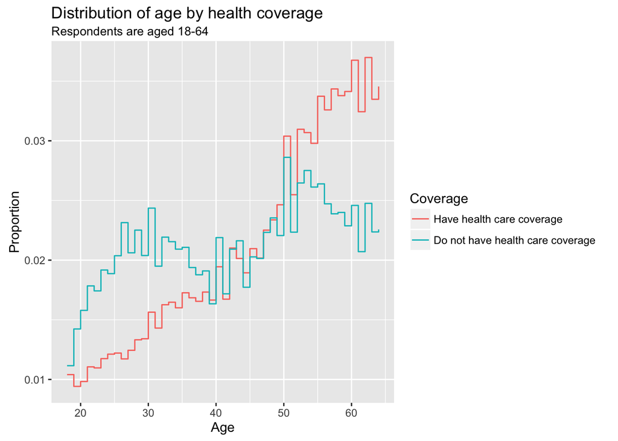

This chart shows young people are more likely to not be insured compared to their older counterparts.

**Research question 1:** Is general health associated to a lack of health care coverage? Let’s look at a contingency table of general health (*genhlth*) and health care coverage (for respondents aged 18-64 with any form of coverage) (*X_hcvu651*):

```
##
##             Have health care coverage Do not have health care coverage
##   Excellent                0.20779316                       0.14874675
##   Very good                0.35726636                       0.26022085
##   Good                     0.28175537                       0.35767232
##   Fair                     0.10718175                       0.17306664
##   Poor                     0.04600336                       0.06029344
```

The proportions vary within general health, which provides evidence that these two variables are associated. We can also look at a couple graphs - first, a histogram:

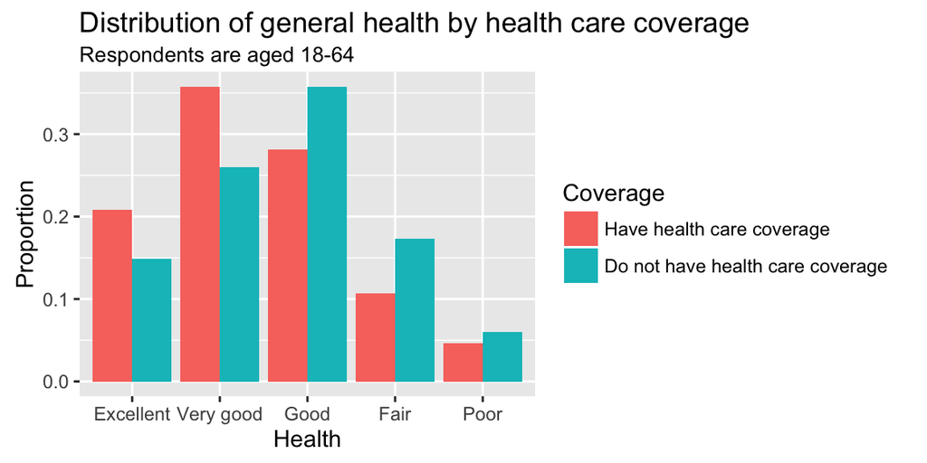

Next, a mosaic-like bar plot:

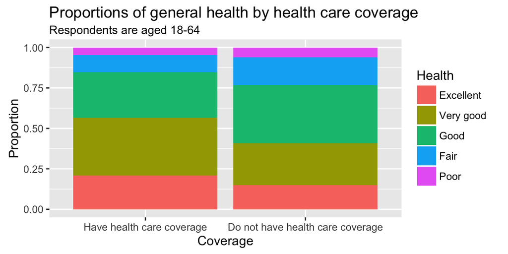

In both these graphs we see that the general health proportions vary by coverage, which provides visual evidence that these two variables are associated.

**Research question 2:** Is there an association between health care coverage and not being able to see a doctor because of cost? Here’s another contingency table, this time of health care coverage (for respondents aged 18-64 with any form of coverage) (*X_hcvu651*) and not being able to see the doctor due to cost (*medcost*):

```
##
##                                          Yes        No
##   Have health care coverage        0.1028146 0.8971854
##   Do not have health care coverage 0.4670420 0.5329580
```

Of those residents with insurance, about 10% say they couldn’t see the doctor due to cost. This tells me the two variables are associated. We can reach the same conclusion graphically – here’s a mosaic plot:

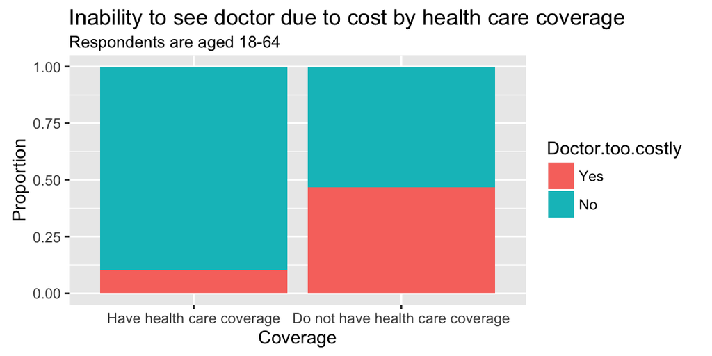

Next I’ll look at the states with the highest proportion of insured residents unable to see the doctor due to cost.

```
## Source: local data frame [53 x 2]
## Groups: State [53]
##
##             State Doctor.too.costly
##            <fctr>             <dbl>
## 1            Guam         0.1760508
## 2     Puerto Rico         0.1497283
## 3         Florida         0.1490275
## 4     Mississippi         0.1482208
## 5         Georgia         0.1315734
## 6      New Mexico         0.1294214
## 7        Kentucky         0.1280133
## 8       Louisiana         0.1280030
## 9  South Carolina         0.1274182
## 10       Arkansas         0.1258306
## # ... with 43 more rows
```

The first two are territories. The rest of the top ten entries are states with varying demographics: New Mexico has a large share of hispanics, Mississippi is the poorest state, Florida has a high percentage of retirees… I’m curious as to the driving force behind these proportions. Is it correlated to the state’s uninsured rate?

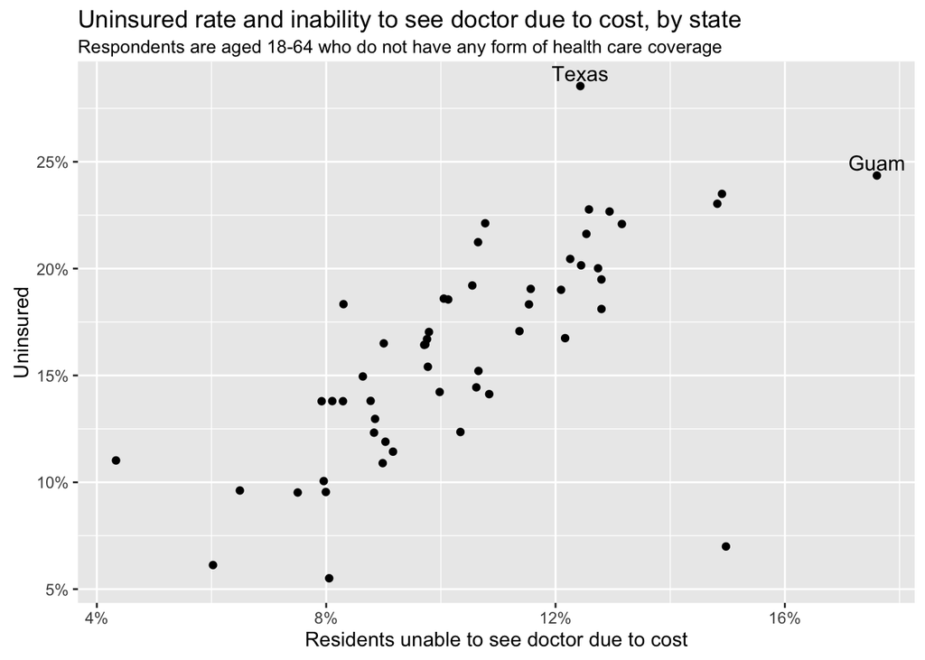

Visually the correlation seems pretty high - as the uninsured rate increases, so does the state’s proportion of residents unable to see the doctor due to cost. Maybe this is a flawed comparison: if a state has a high number of uninsured residents, then most likely a large proportion of them will not be able to see the doctor, unless the median income is really high – correct? I’m not 100% sure on the validity of this graph, so I’ll keep it here – it is visually compelling.

**Research question 3:** Finally, is there an association between insurance and the flu vaccine? I’ll answer that with a contingency table of coverage and getting the flu shot within the last 12 months (*flushot6*):

```
##
##                                          Yes        No
##   Have health care coverage        0.4199200 0.5800800
##   Do not have health care coverage 0.1963255 0.8036745
```

About 42% of insured residents got the shot. This shows that the two variables are associated (if not, we would expect the rate to be more like 50%). It’s also interesting to note that about 20% of uninsured residents got the shot.

What states have the lowest proportion of insured residents that got the flu shot within the last 12 months?

```
## Source: local data frame [53 x 2]
## Groups: State [53]
##
##          State Shot.proportion
##         <fctr>           <dbl>
## 1  Puerto Rico       0.1700168
## 2      Florida       0.3285757
## 3      Arizona       0.3351092
## 4         Guam       0.3359649
## 5       Nevada       0.3461228
## 6        Idaho       0.3473326
## 7    Wisconsin       0.3660977
## 8   New Jersey       0.3718763
## 9       Alaska       0.3724138
## 10     Indiana       0.3762512
## # ... with 43 more rows
```

The first entry here, Puerto Rico, was also in the top two in the previous list of states with the highest proportion of insured residents unable to see the doctor due to cost. The others are not all alike: Arizona, Wisconsin, Idaho, Alaska… interesting. Like before, let’s see if there’s a correlation with uninsured rates:

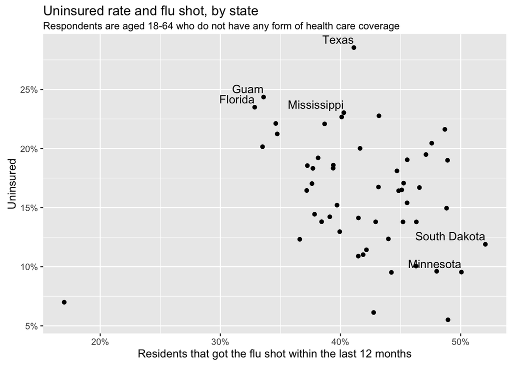

Interesting! This time the correlation is not as strong. There might be other things driving people to get/avoid the vaccine, including education, rural makeup, religious exemptions, etc.